# Exp2_data

Mrudula

06/11/2020

This is the Data Analysis collected from Prolific for the second version of the Overshadowing Experiment where the distractor words are closer to the center and the number appears either at the top or bottom.

The design looks like this.

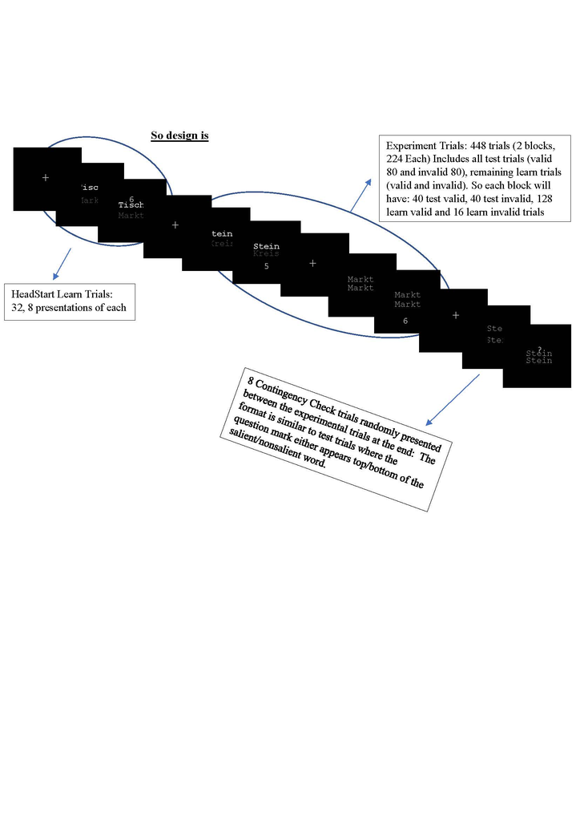

Design of the experiment.

Loading the libraries and the relevant data files

2. Checking balance in design and all trials and conditions are balanced.

Cleaning data : removing unnecessaary columns, filling Screen background and block count to every cell, splitting the RT column and changed the units to ms and creating a column for Error Rate. Also creating another dataframe containing the Contingency AWareness(CA) trials and the AWareness questionnaire.

### Demographics

Mean Age of participants

| Min. | 1st Qu. | Median | Mean | 3rd Qu. | Max. |
| --- | --- | --- | --- | --- | --- |
| 18 | 23.75 | 25.5 | 26.23 | 30 | 34 |

Gender distribution

| Var1 | Freq |
| --- | --- |
| female | 18 |
| male | 22 |

Mean RT

| Min. | 1st Qu. | Median | Mean | 3rd Qu. | Max. |
| --- | --- | --- | --- | --- | --- |
| 17.86 | 498.3 | 564.6 | 602.1 | 645.5 | 74496 |

Accuracy

| 0 | 1 |
| --- | --- |
| 985 | 18215 |

Percentage of errors

| 0 | 1 |
| --- | --- |
| 5.13 | 94.87 |

### Exclusion of Outliers and Farouts

Removing outliers and farouts and showing the summary of RTs for each exclusion criteria

Summary of RT after removing Farouts

| Min. | 1st Qu. | Median | Mean | 3rd Qu. | Max. | NA’s |
| --- | --- | --- | --- | --- | --- | --- |
| 310 | 500 | 565.1 | 585.7 | 642.8 | 1453 | 1265 |

Summary of RT after removing Outliers

| Min. | 1st Qu. | Median | Mean | 3rd Qu. | Max. | NA’s |
| --- | --- | --- | --- | --- | --- | --- |
| 310 | 498.2 | 561.3 | 574.6 | 634 | 1195 | 1829 |

## Analysis of Validity across all trials

- **ANOVA**:

  | Effect | DFn | DFd | SSn | SSd | F | p | p<.05 | ges |
  | --- | --- | --- | --- | --- | --- | --- | --- | --- |
  | (Intercept) | 1 | 39 | 55316933 | 582899 | 3701 | 2.886e-40 | * | 0.989 |
  | Validity | 1 | 39 | 2694 | 11630 | 9.033 | 0.004618 | * | 0.004371 |
  | Condition | 1 | 39 | 133.1 | 9961 | 0.5209 | 0.4747 |  | 0.0002168 |
  | Validity:Condition | 1 | 39 | 230.7 | 9088 | 0.9902 | 0.3258 |  | 0.0003759 |

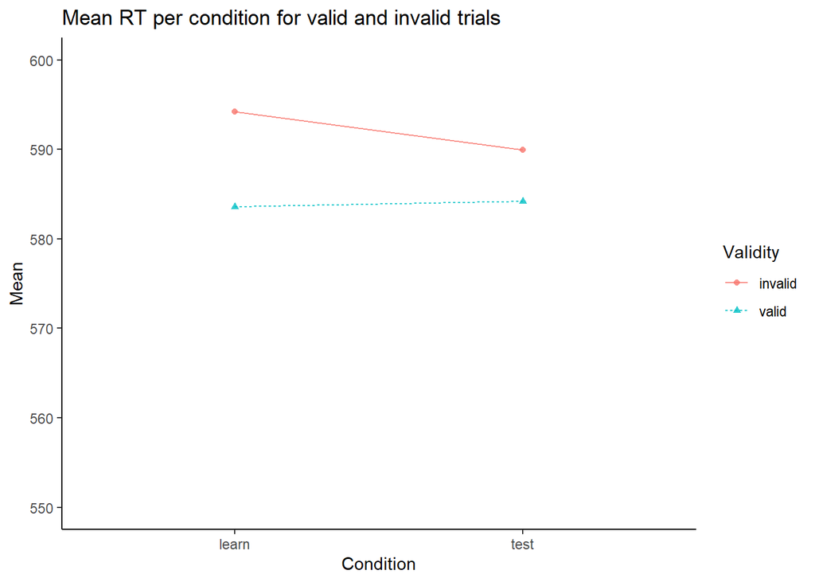

## Analysis for learn trials

#### 1. Farouts

A strong validity effect between valid learn trials and invalid learn trials

Paired t-test: `RT_ifo` by `Validity`

| Test statistic | df | P value | Alternative hypothesis | mean of the differences |
| --- | --- | --- | --- | --- |
| 2.752 | 39 | 0.008941 * * | two.sided | 10.61 |

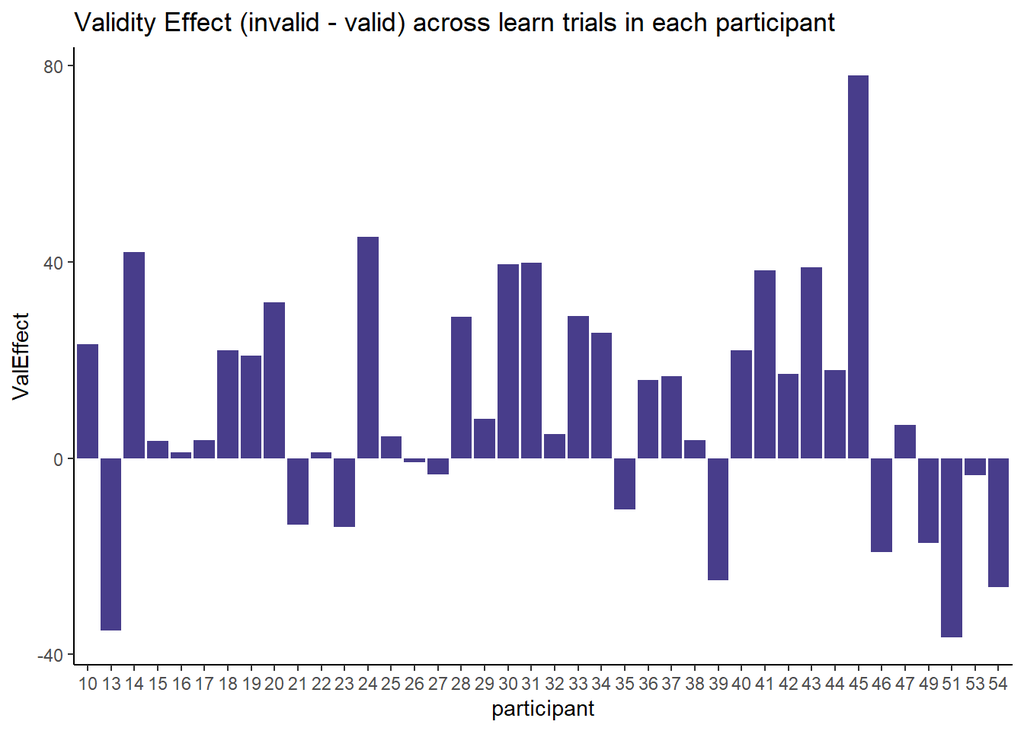

#### 2. Outliers

Paired t-test: `RT_io` by `Validity`

| Test statistic | df | P value | Alternative hypothesis | mean of the differences |
| --- | --- | --- | --- | --- |
| 1.715 | 39 | 0.09433 | two.sided | 5.898 |

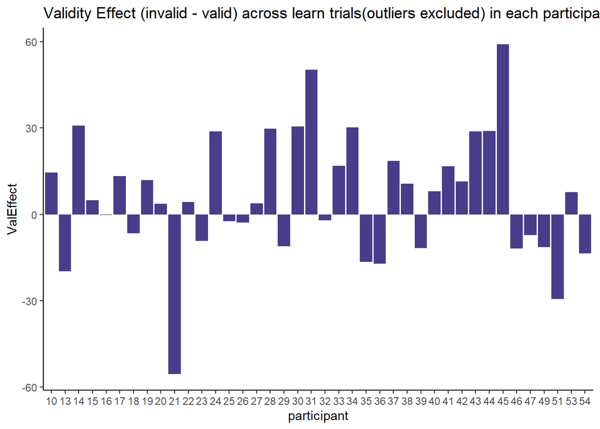

#### 3. Error Rate

No significant difference in ER

t test results for error Rates

| Test statistic | df | P value | Alternative hypothesis | mean of the differences |
| --- | --- | --- | --- | --- |
| 0.2003 | 39 | 0.8423 | two.sided | 0.001649 |

## Analysis of Test Trials

#### 1. Farouts

Almost significant validity effect = p.10. But no main effect of Saliency or interaction between saliency and validity.

- **ANOVA**:

  | Effect | DFn | DFd | SSn | SSd | F | p | p<.05 | ges |
  | --- | --- | --- | --- | --- | --- | --- | --- | --- |
  | (Intercept) | 1 | 39 | 55142198 | 631044 | 3408 | 1.419e-39 | * | 0.9878 |
  | Saliency | 1 | 39 | 35.98 | 11255 | 0.1247 | 0.7259 |  | 5.296e-05 |
  | Validity | 1 | 39 | 1302 | 18360 | 2.766 | 0.1043 |  | 0.001914 |
  | Saliency:Validity | 1 | 39 | 7.576 | 18558 | 0.01592 | 0.9002 |  | 1.115e-05 |

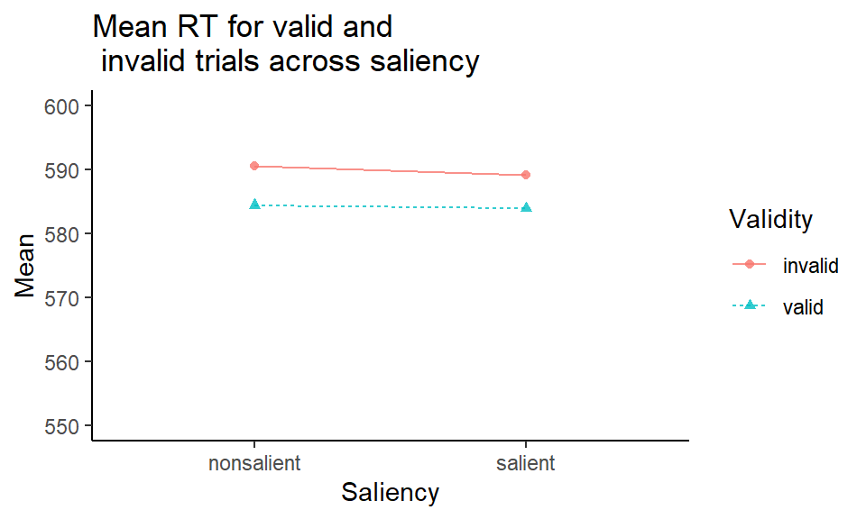

[figure not shown]

#### 2. Outliers

Validity effect, p = 0.19 but main effect of saliency and interaction between saliency and validity are far from being significant

- **ANOVA**:

  | Effect | DFn | DFd | SSn | SSd | F | p | p<.05 | ges |
  | --- | --- | --- | --- | --- | --- | --- | --- | --- |
  | (Intercept) | 1 | 39 | 53159851 | 573138 | 3617 | 4.489e-40 | * | 0.9888 |
  | Saliency | 1 | 39 | 19.52 | 8479 | 0.0898 | 0.766 |  | 3.234e-05 |
  | Validity | 1 | 39 | 520.7 | 11733 | 1.731 | 0.196 |  | 0.0008618 |
  | Saliency:Validity | 1 | 39 | 22.88 | 10280 | 0.08679 | 0.7699 |  | 3.79e-05 |

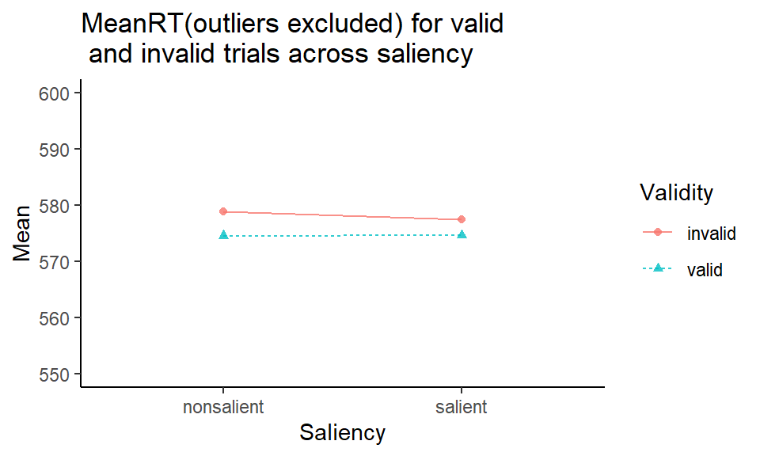

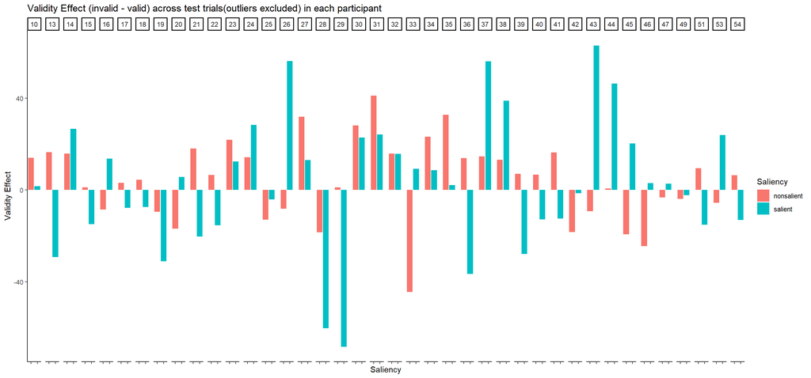

### 3. Error Rate

No significant effect of ER

# Exploratory Analysis

## 1. Effect of screen background

For the white background the responses are faster and behave as expected. Whereas, for the black background the responses are slower with a different kind of trend (almost like the opposite of the white background results)

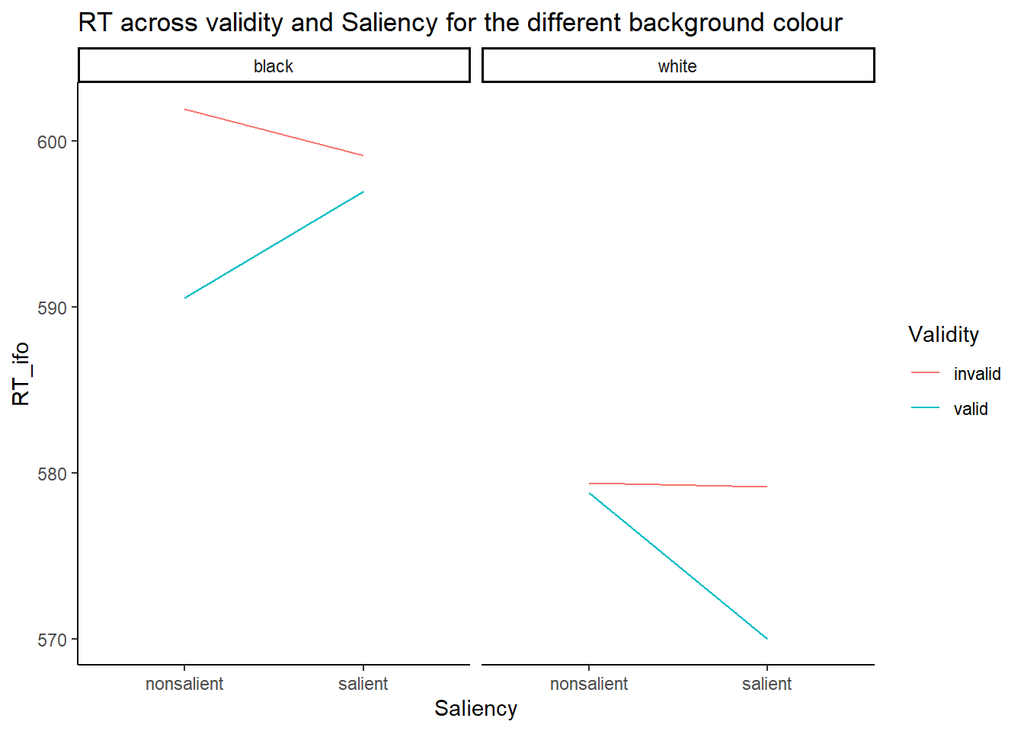

- **ANOVA**:

  | Effect | DFn | DFd | SSn | SSd | F | p | p<.05 | ges |
  | --- | --- | --- | --- | --- | --- | --- | --- | --- |
  | (Intercept) | 1 | 18 | 25228309 | 182312 | 2491 | 9.373e-21 | * | 0.9922 |
  | Saliency | 1 | 18 | 273.8 | 4449 | 1.108 | 0.3065 |  | 0.001381 |
  | Validity | 1 | 18 | 662.8 | 4517 | 2.641 | 0.1215 |  | 0.003335 |
  | Saliency:Validity | 1 | 18 | 428.2 | 6781 | 1.137 | 0.3005 |  | 0.002157 |

- **ANOVA**:

  | Effect | DFn | DFd | SSn | SSd | F | p | p<.05 | ges |
  | --- | --- | --- | --- | --- | --- | --- | --- | --- |
  | (Intercept) | 1 | 20 | 29931110 | 431511 | 1387 | 5.961e-20 | * | 0.9848 |
  | Saliency | 1 | 20 | 55.67 | 6512 | 0.171 | 0.6836 |  | 0.0001203 |
  | Validity | 1 | 20 | 640.9 | 13841 | 0.9261 | 0.3474 |  | 0.001383 |
  | Saliency:Validity | 1 | 20 | 551.4 | 10805 | 1.021 | 0.3244 |  | 0.00119 |

## 2. Adding the factor of Position

This analysis discusses the effect of salient word and the position of the number. Position Match variable indicates whether the salient word position and the target number, appeared in the same place or not. This is a possible test of saliency Manipulation

### Analysis of learn trials - Position

#### 1. Farouts

Significant main validity effect when position Match is factored in.

- **ANOVA**:

  | Effect | DFn | DFd | SSn | SSd | F | p | p<.05 | ges |
  | --- | --- | --- | --- | --- | --- | --- | --- | --- |
  | (Intercept) | 1 | 39 | 55473825 | 551537 | 3923 | 9.395e-41 | * | 0.9887 |
  | Validity | 1 | 39 | 4353 | 23675 | 7.171 | 0.01079 | * | 0.006789 |
  | PositionMatch | 1 | 39 | 798.6 | 35972 | 0.8659 | 0.3578 |  | 0.001253 |
  | Validity:PositionMatch | 1 | 39 | 197.3 | 25630 | 0.3002 | 0.5869 |  | 0.0003097 |

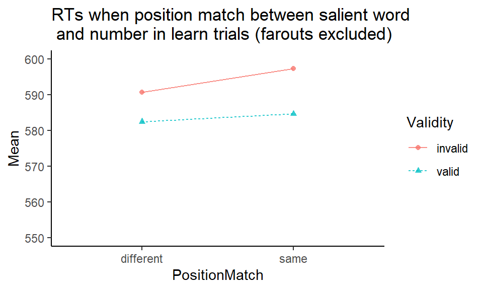

#### 2. Outliers

Almost significant validity effect(p = .09) when PositionMatch of salient word and number is factored in the ANOVA

- **ANOVA**:

  | Effect | DFn | DFd | SSn | SSd | F | p | p<.05 | ges |
  | --- | --- | --- | --- | --- | --- | --- | --- | --- |
  | (Intercept) | 1 | 39 | 53045290 | 515871 | 4010 | 6.132e-41 | * | 0.9891 |
  | Validity | 1 | 39 | 1396 | 19122 | 2.848 | 0.09946 |  | 0.002389 |
  | PositionMatch | 1 | 39 | 320.6 | 25609 | 0.4882 | 0.4889 |  | 0.0005494 |
  | Validity:PositionMatch | 1 | 39 | 97.97 | 22500 | 0.1698 | 0.6825 |  | 0.000168 |

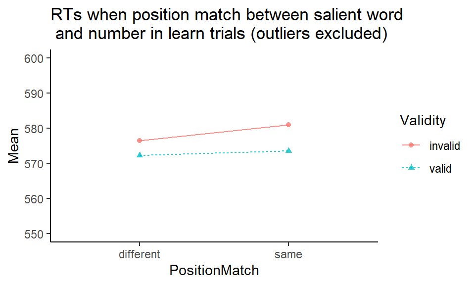

#### 3. Error Rate

No significant ER

### Analysis of test trials - Position

#### 1. Farouts

Main effect of Validity when Position of Number is factored in is almost significant , p = .10

- **ANOVA**:

  | Effect | DFn | DFd | SSn | SSd | F | p | p<.05 | ges |
  | --- | --- | --- | --- | --- | --- | --- | --- | --- |
  | (Intercept) | 1 | 39 | 110280527 | 1264796 | 3401 | 1.479e-39 | * | 0.9868 |
  | Validity | 1 | 39 | 2603 | 36276 | 2.798 | 0.1024 |  | 0.001758 |
  | PositionT | 1 | 39 | 37.09 | 31127 | 0.04647 | 0.8304 |  | 2.509e-05 |
  | Saliency | 1 | 39 | 42.43 | 22431 | 0.07377 | 0.7874 |  | 2.87e-05 |
  | Validity:PositionT | 1 | 39 | 730.8 | 32990 | 0.8639 | 0.3584 |  | 0.0004942 |
  | Validity:Saliency | 1 | 39 | 18.35 | 36930 | 0.01938 | 0.89 |  | 1.242e-05 |
  | PositionT:Saliency | 1 | 39 | 5.963 | 20384 | 0.01141 | 0.9155 |  | 4.034e-06 |
  | Validity:PositionT:Saliency | 1 | 39 | 69.44 | 33149 | 0.0817 | 0.7765 |  | 4.698e-05 |

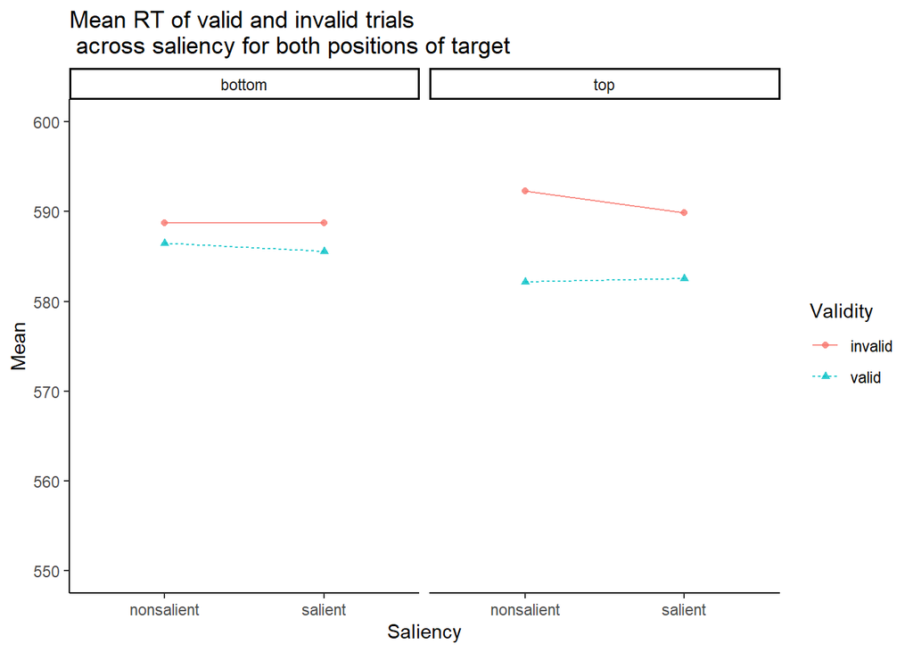

#### 2. Outliers

- **ANOVA**:

  | Effect | DFn | DFd | SSn | SSd | F | p | p<.05 | ges |
  | --- | --- | --- | --- | --- | --- | --- | --- | --- |
  | (Intercept) | 1 | 39 | 106348427 | 1149285 | 3609 | 4.698e-40 | * | 0.9881 |
  | Validity | 1 | 39 | 1089 | 23108 | 1.838 | 0.1829 |  | 0.0008467 |
  | PositionT | 1 | 39 | 979.5 | 19560 | 1.953 | 0.1702 |  | 0.0007614 |
  | Saliency | 1 | 39 | 26.08 | 16334 | 0.06227 | 0.8043 |  | 2.029e-05 |
  | Validity:PositionT | 1 | 39 | 171.3 | 20070 | 0.3329 | 0.5673 |  | 0.0001332 |
  | Validity:Saliency | 1 | 39 | 46.96 | 20564 | 0.08906 | 0.767 |  | 3.653e-05 |
  | PositionT:Saliency | 1 | 39 | 601.9 | 13681 | 1.716 | 0.1979 |  | 0.0004681 |
  | Validity:PositionT:Saliency | 1 | 39 | 238.7 | 22793 | 0.4084 | 0.5265 |  | 0.0001857 |

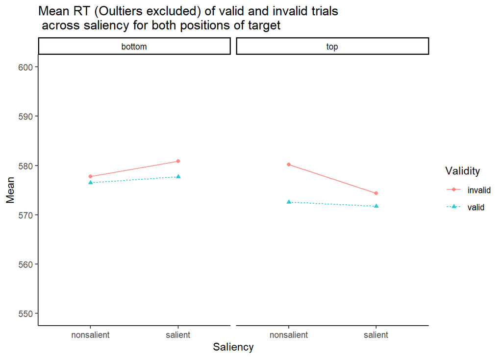

#### 3. Error Rate

No significant difference in Error Rate

## Contingency Awareness Analysis

The total accuracy in the Contingency AWareness(CA) trials for each participant is computed. They can score a maximum of 8. The replies to the questionnaire are also coded as follows:

- People who said yes to seeing a pattern with an even number
- People who said yes for seeing a pattern with an odd number
- Participants who said no for seeing a pattern for even responses
- Participants who said no for seeing a pattern for odd responses
- Total number of accurate responses for Word predictions

THe score for each participant is plotted to identify the ones who scored more than average.

[figure not shown]

### 1. ANOVA after selecting only participants who did better in CA trials

Strong validity effect along with a strong interaction between validity and Saliency

- **ANOVA**:

  | Effect | DFn | DFd | SSn | SSd | F | p | p<.05 | ges |
  | --- | --- | --- | --- | --- | --- | --- | --- | --- |
  | (Intercept) | 1 | 14 | 19383784 | 125454 | 2163 | 9.551e-17 | * | 0.993 |
  | Saliency | 1 | 14 | 519.5 | 3392 | 2.144 | 0.1652 |  | 0.003787 |
  | Validity | 1 | 14 | 2281 | 3964 | 8.058 | 0.01314 | * | 0.01642 |
  | Saliency:Validity | 1 | 14 | 2412 | 3835 | 8.806 | 0.01019 | * | 0.01735 |

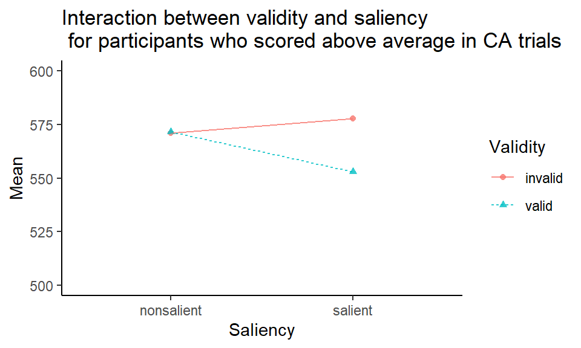

### 2. ANOVA for participants who scored below average

Marginal significance of Saliency x Validity interaction with a reversed pattern

- **ANOVA**:

  | Effect | DFn | DFd | SSn | SSd | F | p | p<.05 | ges |
  | --- | --- | --- | --- | --- | --- | --- | --- | --- |
  | (Intercept) | 1 | 24 | 35791887 | 472117 | 1819 | 3.844e-24 | * | 0.9861 |
  | Saliency | 1 | 24 | 101.4 | 7278 | 0.3342 | 0.5686 |  | 0.0002013 |
  | Validity | 1 | 24 | 74.8 | 13342 | 0.1345 | 0.717 |  | 0.0001486 |
  | Saliency:Validity | 1 | 24 | 1724 | 10594 | 3.906 | 0.05971 |  | 0.003414 |

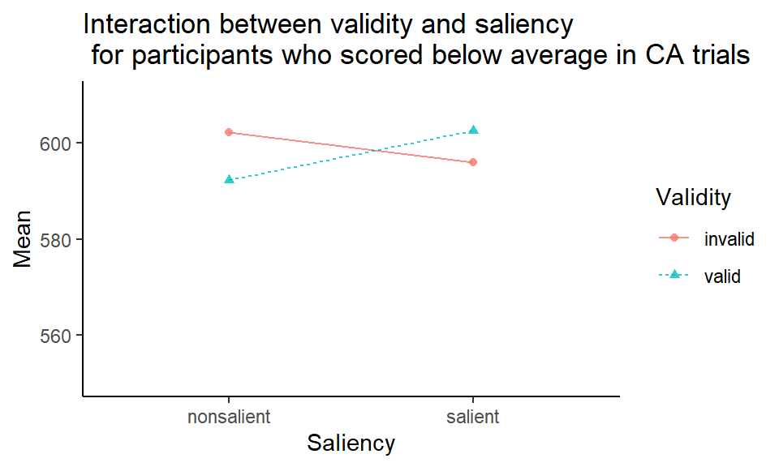